# Assignment 3

Ashani Jayasekera

2024-10-02

## Git and GitHub

The link to the Github repository where Assignment 3 can be found at https://github.com/ashanijay/SURV727.

## Web Scraping

The html from the url is scrapped from the web.

```r
url <- read_html("https://en.wikipedia.org/wiki/Grand_Boulevard,_Chicago")
```

# Gather the tables.

All the tables are scrapped using the url’s html. The historical population table extracted in particular and printed.

```r
allTables <- html_table(url)
class(allTables)
```

```
## [1] "list"
```

```r
str(allTables)
```

[output not shown]

[output cut: 23 more lines]

```r
##pull the historical population table
hist.pop.table <- allTables[[2]]
print(hist.pop.table)
```

```
## # A tibble: 11 × 4
##    Census Pop.    .mw-parser-output .sr-only{border:0;clip:rect(0,0,0,0)…¹ `%±`
##    <chr>  <chr>   <chr>                                                    <chr>
##  1 1930   87,005  ""                                                       —
##  2 1940   103,256 ""                                                       18.7%
##  3 1950   114,557 ""                                                       10.9%
##  4 1960   80,036  ""                                                       −30.…
##  5 1970   80,166  ""                                                       0.2%
##  6 1980   53,741  ""                                                       −33.…
##  7 1990   35,897  ""                                                       −33.…
##  8 2000   28,006  ""                                                       −22.…
##  9 2010   21,929  ""                                                       −21.…
## 10 2020   24,589  ""                                                       12.1%
## 11 [3][1] [3][1]  "[3][1]"                                                 [3][…
## # ℹ abbreviated name:
## #   ¹`.mw-parser-output .sr-only{border:0;clip:rect(0,0,0,0);clip-path:polygon(0px 0px,0px 0px,0px 0px);height:1px;margin:-1px;overflow:hidden;padding:0;position:absolute;width:1px;white-space:nowrap}Note`
```

# Additional table formatting.

The final table, after formatting, is below.

```r
pop <- hist.pop.table[1:10, -3]
pop
```

```
## # A tibble: 10 × 3
##    Census Pop.    `%±`
##    <chr>  <chr>   <chr>
##  1 1930   87,005  —
##  2 1940   103,256 18.7%
##  3 1950   114,557 10.9%
##  4 1960   80,036  −30.1%
##  5 1970   80,166  0.2%
##  6 1980   53,741  −33.0%
##  7 1990   35,897  −33.2%
##  8 2000   28,006  −22.0%
##  9 2010   21,929  −21.7%
## 10 2020   24,589  12.1%
```

# Grab the community areas east of Grand Boulevard and save them as a character vector.

The printed vector of community areas east of Grand Boulevard is below.

```r
adjacent.places <- allTables[[3]]
east.places <- unlist(as.vector(adjacent.places[-1,3]))
east.places <- east.places[!east.places == ""]
places_east <- gsub(" ", "_", east.places)
print(places_east)
```

```
##
##   "Oakland,_Chicago"   "Kenwood,_Chicago" "Hyde_Park,_Chicago"
```

# Build a small loop.

```r
pops <- pop
```

A loop was used to grab the population tables from each of the pages that correspond to the neighboring neighborhoods. The columns are appended to the exisitng table. The final table is printed below.

```r
for (i in places_east){
  base_url <- "https://en.wikipedia.org/wiki/"
  new_url <- paste0(base_url, i)
  my.url <- read_html(new_url)
  allTables <- html_table(my.url)
  hist.pop.table <- allTables[[2]][1:10, -3]
  pops <- cbind(pops, hist.pop.table)
}
print(pops)
```

```
##    Census    Pop.     %± Census   Pop.     %± Census   Pop.     %± Census
## 1    1930  87,005      —   1910 13,763      —   1930 26,942      —   1930
## 2    1940 103,256  18.7%   1920 16,540  20.2%   1940 29,611   9.9%   1940
## 3    1950 114,557  10.9%   1930 14,962  −9.5%   1950 35,705  20.6%   1950
## 4    1960  80,036 −30.1%   1940 14,500  −3.1%   1960 41,533  16.3%   1960
## 5    1970  80,166   0.2%   1950 24,464  68.7%   1970 26,890 −35.3%   1970
## 6    1980  53,741 −33.0%   1960 24,378  −0.4%   1980 21,974 −18.3%   1980
## 7    1990  35,897 −33.2%   1970 18,291 −25.0%   1990 18,178 −17.3%   1990
## 8    2000  28,006 −22.0%   1980 16,748  −8.4%   2000 18,363   1.0%   2000
## 9    2010  21,929 −21.7%   1990  8,197 −51.1%   2010 17,841  −2.8%   2010
## 10   2020  24,589  12.1%   2000  6,110 −25.5%   2020 19,116   7.1%   2020
##      Pop.     %±
## 1  48,017      —
## 2  50,550   5.3%
## 3  55,206   9.2%
## 4  45,577 −17.4%
## 5  33,531 −26.4%
## 6  31,198  −7.0%
## 7  28,630  −8.2%
## 8  29,920   4.5%
## 9  25,681 −14.2%
## 10 29,456  14.7%
```

## Scraping and Analysxing Text Data

# Scrape the text without any of the information.

The text is scrapped without any of the information in the margins and headers. The first description is printed below.

```r
library(tibble)
my.url <- read_html("https://en.wikipedia.org/wiki/Grand_Boulevard,_Chicago")
text <- html_text(html_nodes(my.url, xpath = '//p'))
description <-text %>% paste(collapse = ' ')
descriptions <- tibble(data.frame(Location = "Grand_Boulevard,_Chicago", Text_Description = description))
print(descriptions)
```

```
## # A tibble: 1 × 2
##   Location                 Text_Description
##   <chr>                    <chr>
## 1 Grand_Boulevard,_Chicago "\n Grand Boulevard on the South Side of Chicago, Il…
```

# Create a tibble with the location and the text using a loop.

The descriptions are printed below using a similar loop as below.

```r
for (i in places_east){
  base_url <- "https://en.wikipedia.org/wiki/"
  new_url <- paste0(base_url, i)
  my.url <- read_html(new_url)
  text <- html_text(html_nodes(my.url, xpath = '//p'))
  description <-text %>% paste(collapse = ' ')
  description <- tibble(data.frame(Location = i, Text_Description = description))
  descriptions <- rbind(descriptions, description)
}
print(descriptions)
```

```
## # A tibble: 4 × 2
##   Location                 Text_Description
##   <chr>                    <chr>
## 1 Grand_Boulevard,_Chicago "\n Grand Boulevard on the South Side of Chicago, Il…
## 2 Oakland,_Chicago         "Oakland, located on the South Side of Chicago, Illi…
## 3 Kenwood,_Chicago         "\n Kenwood, one of Chicago's 77 community areas, is…
## 4 Hyde_Park,_Chicago       "\n Hyde Park is a neighborhood on the South Side of…
```

# Create tokens.

The most common words overall are “park,” “hyde,” “chicago,” “kenwood,” and “street.”

```r
library(tidytext)
library(dplyr)
##need to convert the data so that it has one-token-per-document-per-row

tidy_descriptions <- descriptions %>%
  unnest_tokens(word, Text_Description)

##remove stop words
data(stop_words)
tidy_descriptions <- tidy_descriptions %>%
  anti_join(stop_words)
##find the most common words in all the descriptions
common_words <- tidy_descriptions %>%
  count(word, sort = T)
print(common_words)
```

```
## # A tibble: 1,141 × 2
##    word             n
##    <chr>        <int>
##  1 park            85
##  2 hyde            75
##  3 chicago         57
##  4 kenwood         40
##  5 street          38
##  6 south           29
##  7 community       28
##  8 neighborhood    26
##  9 oakland         25
## 10 lake            23
## # ℹ 1,131 more rows
```

# Plot the common words with each location.

See the plots below. The most common words for each town are the names of the town itself and often the city of “Chicago” is mentioned. Some of the differences in the most common words are: Grand Boulevard, Chicago has words that describe the people that live in the “community” using words like “residents” and “american.” Hyde Park, Chicago has words that describe nature including “lake” and academia using the word “university.” Kenwood, Chicago has words that desribe the community and schooling. It also has the names of some of the neighboring towns. Oakland, Chicago has words that desribe the building and homes in the town. The word “lake” is also mentioned like in Hyde Park. Community is also mentioned like Grand Boulevard and Kenwood.

```
## $`Grand_Boulevard,_Chicago`
```

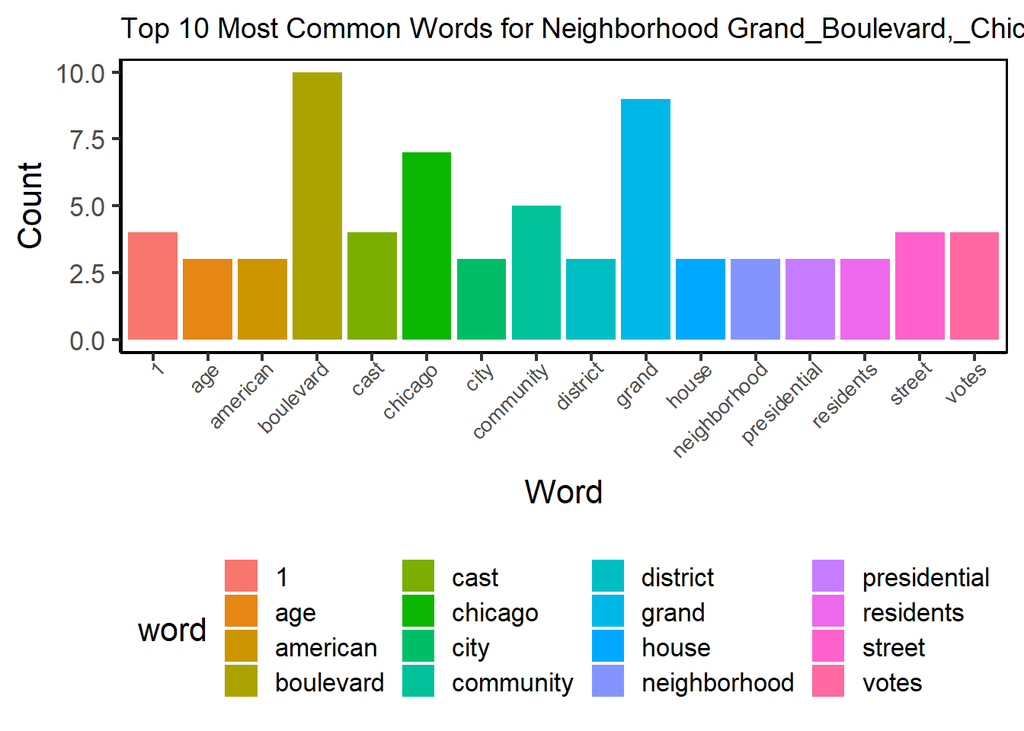

```
##
## $`Hyde_Park,_Chicago`
```

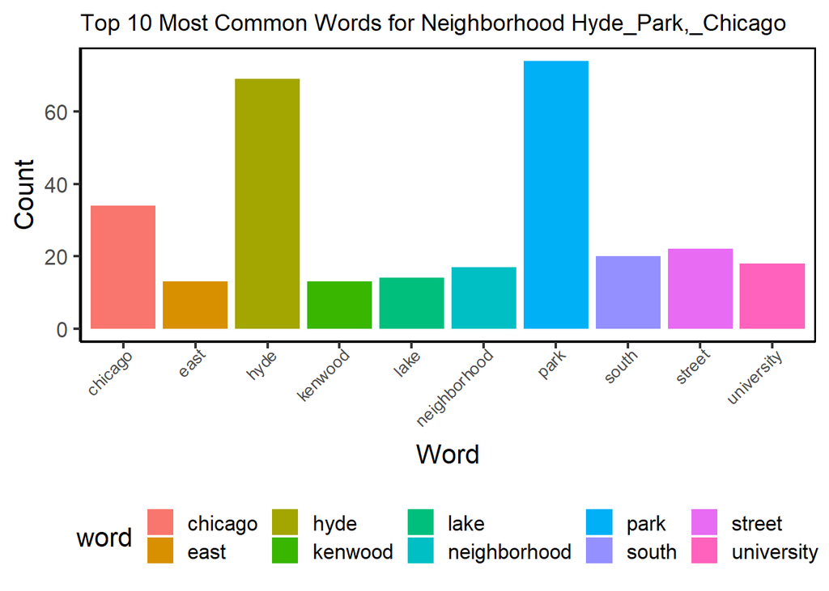

```
##
## $`Kenwood,_Chicago`
```

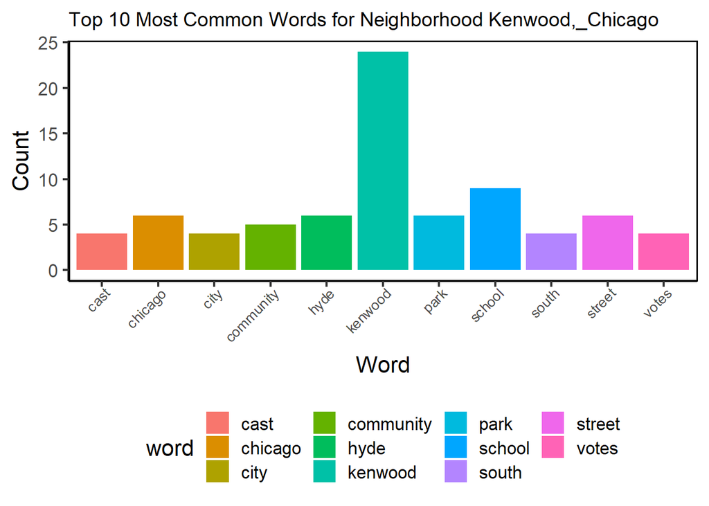

```
##
## $`Oakland,_Chicago`
```

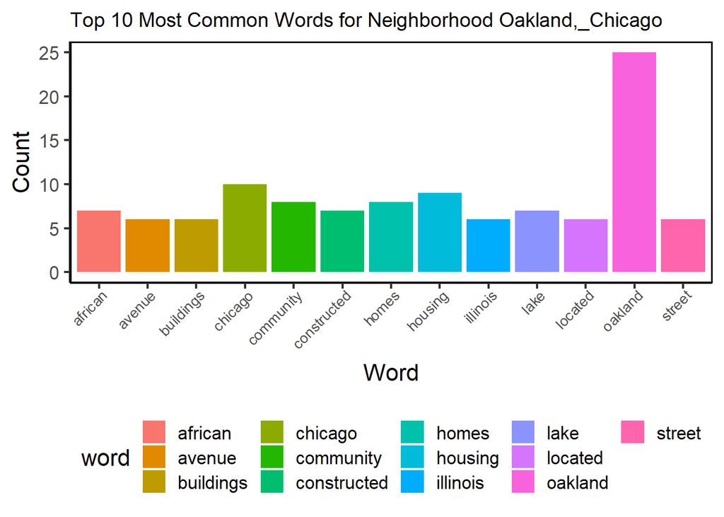

```r
##plot the common words within each location
common_words_location <- tidy_descriptions %>%
     group_by(Location) %>%
     count(word, sort = T)

mostCom_location <- common_words_location %>% group_by(Location) %>% slice_max(c(`n`), n = 10)

library(ggplot2)
df_split <- split(mostCom_location, mostCom_location$Location)

lapply(df_split, function(df) {
  ggplot(df, aes(x = word, y = n, group = Location, fill = word)) +
    geom_col() +
    theme_classic(base_size = 16) +
      labs(y= "Count", x= "Word", title = paste0("Top 10 Most Common Words for Neighborhood ", df$Location[1]))+
    theme(panel.grid.major = element_blank(),
        panel.grid.minor = element_blank(),
        panel.background = element_rect(colour = "black", size=1),
        strip.background = element_blank(),
        panel.spacing = unit(2, "lines"),
        legend.position="bottom",
        legend.direction = "horizontal",
        plot.title= element_text(size = 14),
        axis.text.x = element_text(angle = 45, vjust = 1.1, hjust=1,size = 10))

})
```